# Survival effects of strong autocorrelation and hot average temperatures

Debora

2024-02-27

## H2: Effect of initial conditions

When temperatures are strongly autocorrelated and average is higher than optimal:

- Hot start: negative impact to performance
- Cold start: positive impact to performance

This is not observed in other average temperatures (due to the asymmetrical shape of thermal performance curves: prolonged exposures to temperatures either above or below the average typical of strongly autocorrelated thermal regimes are not as detrimental as average temperatures approaching the upper thermal limit)

### Dataset: each row of the dataset corresponds to a single frond which either survived (1) or did not survive (0) at the end of the experiment

| Experiment_Number | Mean_temperature | survival | Treatment |
| --- | --- | --- | --- |
| 85 | 37 | 1 | no autocorrelation |
| 85 | 37 | 1 | no autocorrelation |
| 85 | 37 | 1 | no autocorrelation |
| 85 | 37 | 1 | no autocorrelation |
| 112 | 37 | 0 | hot-cold |
| 112 | 37 | 0 | hot-cold |
| 112 | 37 | 0 | hot-cold |
| 112 | 37 | 0 | no autocorrelation |
| 112 | 37 | 0 | no autocorrelation |

### Plotting survival data: each dot also corresponds to a single individual

1 = living frond  
0 = dead frond

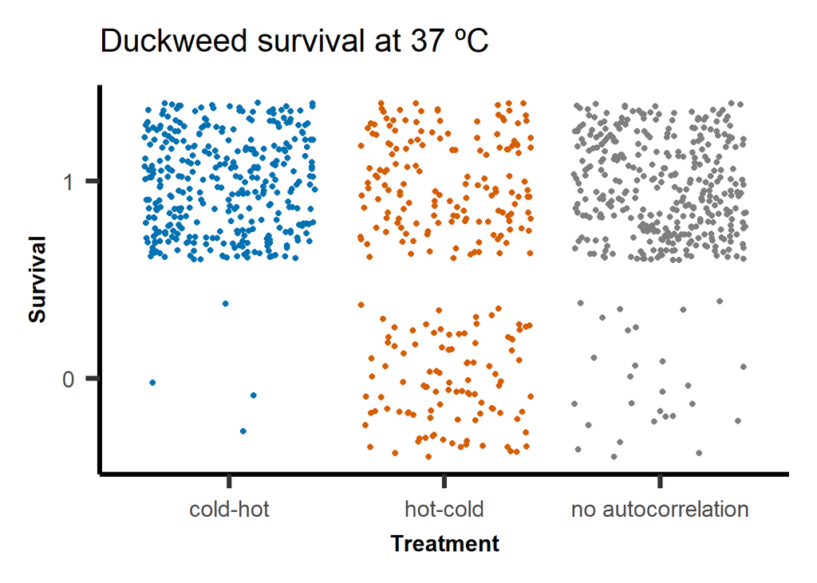

### Candidate models (logistic fit, binomial data)

```r
library(sjPlot)
library(sjmisc)

datins2$Experiment_Number <- as.factor(datins2$Experiment_Number)
datins2$Incubator <- as.factor(datins2$Incubator)

datins2 <- within(datins2, Treatment <- relevel(factor(Treatment), ref = "no autocorrelation"))

# Logistic regression allows categorically and continuously scaled variables to predict any categorically
# scaled criterion (Osborne, J. W. (Ed.). 2008. Best practices in quantitative methods. Sage)

# adding random effects
library(lme4)
glm.fit.sp <- glm(survival ~ Treatment, family = binomial, data=datins2)
experim <- glmer(survival ~ Treatment + (1|Experiment_Number), family=binomial, data=datins2)
incub <- glmer(survival ~ Treatment + (1|Incubator), family=binomial, data=datins2)
inc_exp <- glmer(survival ~ Treatment + (1|Incubator)+(1|Experiment_Number), family=binomial, data=datins2)
exp.inc <- glmer(survival ~ Treatment + (1|Experiment_Number/Incubator), family=binomial, data=datins2)
```

### Model selection: The best model includes incubator number nested in experiment number as a random effect

| Name | Model | AIC | AIC_wt |
| --- | --- | --- | --- |
| no random effects | glm | 588.66 | 0 |
| experiment number | glmerMod | 500.46 | 0 |
| incubator | glmerMod | 569.04 | 0 |
| incubator and experiment number | glmerMod | 494.59 | 0 |
| incubator nested in experiment number | glmerMod | 478.60 | 1 |

### Statistical analysis of selected model

- Model assumptions for over dispersion and normality of random effects were met
- Odds ratio: probability of success / probability of failure
- For categorical predictors, the odds ratio compares the odds of the event occurring for each category of the predictor relative to the reference category, given that all other variables remain constant

|  | survival |  |  |
| --- | --- | --- | --- |
| Predictors | Odds Ratios | CI | p |
| (Intercept) | 28.15 | 8.09 – 97.97 | **<0.001** |
| Treatment [cold-hot] | 8.82 | 1.16 – 66.86 | **0.035** |
| Treatment [hot-cold] | 0.04 | 0.01 – 0.21 | **<0.001** |
| Random Effects |  |  |  |
| σ<sup>2</sup> | 3.29 |  |  |
| τ<sub>00</sub> <sub>Incubator:Experiment_Number</sub> | 2.79 |  |  |
| τ<sub>00</sub> <sub>Experiment_Number</sub> | 1.06 |  |  |
| ICC | 0.54 |  |  |
| N <sub>Incubator</sub> | 4 |  |  |
| N <sub>Experiment_Number</sub> | 14 |  |  |
| Observations | 979 |  |  |
| Marginal R<sup>2</sup> / Conditional R<sup>2</sup> | 0.373 / 0.711 |  |  |

### Area under the curve

- From 0 to 1: refers to the ability of the model to correctly distinguish between the 2 classes

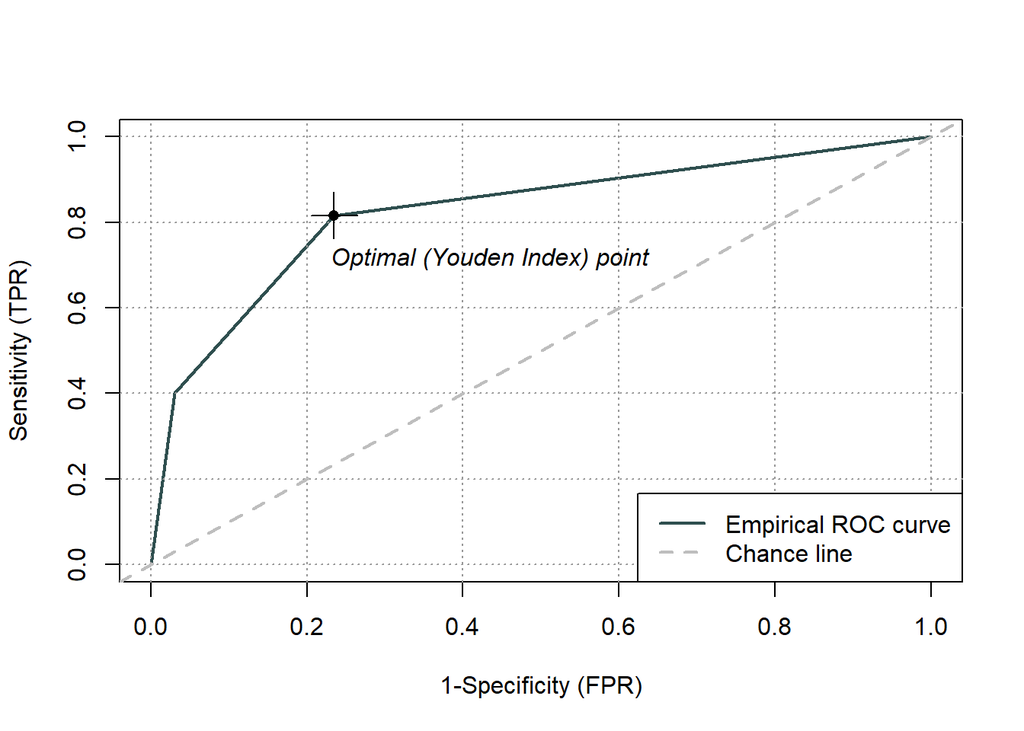

```r
#AUC
glm.probs <- predict(exp.inc,datins2, type = "response")
### Making a receiver operator curve (ROC) to analyze the model performance across several thresholds
library(ROCit)
ROCit_obj <- rocit(score = glm.fit.sp$fitted.values, class = datins2$survival)
plot(ROCit_obj)
```

```r
### Obtaining AUC - area under the curve (maximum is one)
summary(ROCit_obj)
```

```
##
##  Method used: empirical
##  Number of positive(s): 847
##  Number of negative(s): 132
##  Area under curve: 0.8251
```

Sensitivity: proportion of true positives (correctly classified) Specificity: proportion of true negatives (correctly classified)

```r
### Optimal threshold value given by the Youden index
library(pROC)
roc_obj <- roc(datins2$survival, glm.probs)
coords(roc_obj, "best", "threshold")
```

```
##   threshold specificity sensitivity
## 1 0.8720205   0.8863636   0.8193625
```

### Plotting model predictions

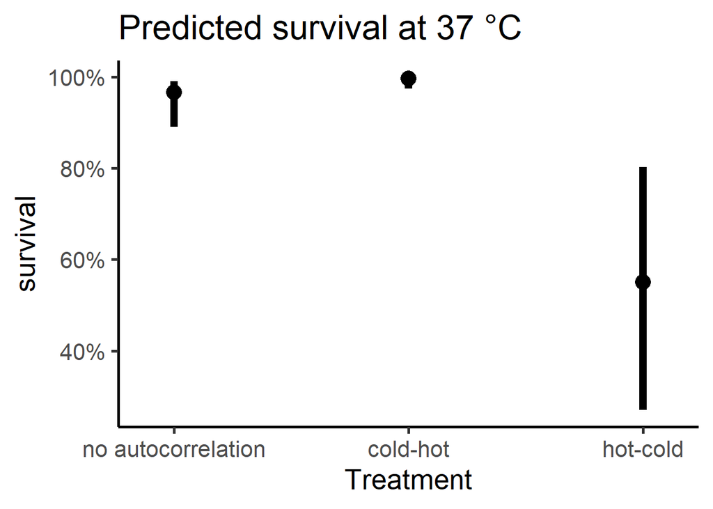

### Post-hoc analyses

| 1 | estimate | SE | df | z.ratio | p.value |
| --- | --- | --- | --- | --- | --- |
| no autocorrelation - (cold-hot) | -2.1767 | 1.0336 | Inf | -2.1059 | 0.0886 |
| no autocorrelation - (hot-cold) | 3.1356 | 0.7925 | Inf | 3.9568 | 0.0002 |
| (cold-hot) - (hot-cold) | 5.3123 | 1.0852 | Inf | 4.8953 | 0.0000 |